# R Notebook

### Analisis Sisaan

Model terbaik hasil identifikasi kemudian dicek asumsi sisaannya. Sisaan model ARIMA harus memenuhi asumsi normalitas, kebebasan, dan kehomogenan ragam. Diagnostik model dilakukan secara eksplorasi dan uji formal.

#### Eksplorasi Sisaan

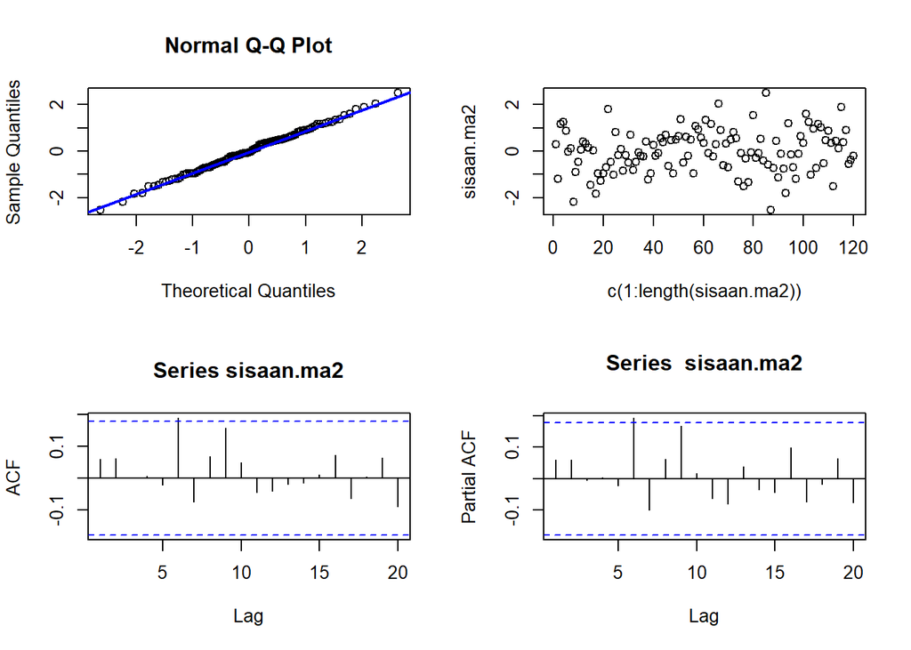

```r
#Eksplorasi
sisaan.ma2 <- model1.ma2$residuals
par(mfrow=c(2,2))
qqnorm(sisaan.ma2)
qqline(sisaan.ma2, col = "blue", lwd = 2)
plot(c(1:length(sisaan.ma2)),sisaan.ma2)
acf(sisaan.ma2)
pacf(sisaan.ma2)
```

```r
par(mfrow = c(1,1))
```

Berdasarkan plot kuantil-kuantil normal, secara eksplorasi ditunjukkan sisaan menyebar normal mengikuti garis $45^{\circ}$. Kemudian dapat dilihat juga lebar pita sisaan yang cenderung sama menandakan bahwa sisaan memiliki ragam yang homogen. Akan tetapi, plot ACF dan PACF sisaan ARIMA(0,0,2) signifikan pada lag ke-6 sehingga sisaan tidak saling bebas. Kondisi ini akan diuji lebih lanjut dengan uji formal.

#### Uji Formal

```r
#1) Sisaan Menyebar Normal
ks.test(sisaan.ma2,"pnorm")
```

```
##
##  Asymptotic one-sample Kolmogorov-Smirnov test
##
## data:  sisaan.ma2
## D = 0.043157, p-value = 0.9788
## alternative hypothesis: two-sided
```

```r
#tak tolak H0 > sisaan menyebar normal
```

Selain dengan eksplorasi, asumsi tersebut dapat diuji menggunakan uji formal. Pada tahapan ini uji formal yang digunakan untuk normalitas adalah uji Kolmogorov-Smirnov (KS). Hipotesis pada uji KS adalah sebagai berikut.

$H_0$ : Sisaan menyebar normal

$H_1$ : Sisaan tidak menyebar normal

Berdasarkan uji KS tersebut, didapat *p-value* sebesar 0.9788 yang lebih besar dari taraf nyata 5% sehingga tak tolak $H_0$ dan menandakan bahwa sisaan menyebar normal. Hal ini sesuai dengan hasil eksplorasi menggunakan plot kuantil-kuantil normal.

```r
#2) Sisaan saling bebas/tidak ada autokorelasi
Box.test(sisaan.ma2, type = "Ljung")
```

```
##
##  Box-Ljung test
##
## data:  sisaan.ma2
## X-squared = 0.43785, df = 1, p-value = 0.5082
```

```r
#tak tolak H0 > sisaan saling bebas
```

Selanjutnya akan dilakukan uji formal untuk kebebasan sisaan menggunakan uji Ljung-Box. Hipotesis yang digunakan adalah sebagai berikut.

$H_0$ : Sisaan saling bebas

$H_1$ : Sisaan tidak tidak saling bebas

Berdasarkan uji Ljung-Box tersebut, didapat *p-value* sebesar 0.5082 yang lebih besar dari taraf nyata 5% sehingga tak tolak $H_0$ dan menandakan bahwa sisaan saling bebas. Hal ini berbeda dengan eksplorasi.

```r
#3) Sisaan homogen
Box.test((sisaan.ma2)^2, type = "Ljung")
```

```
##
##  Box-Ljung test
##
## data:  (sisaan.ma2)^2
## X-squared = 2.4711, df = 1, p-value = 0.116
```

```r
#tak tolak H0 > sisaan homogen
```

Hipotesis yang digunakan untuk uji kehomogenan ragam adalah sebagai berikut.

$H_0$ : Ragam sisaan homogen

$H_1$ : Ragam sisaan tidak homogen

Berdasarkan uji Ljung-Box terhadap sisaan kuadrat tersebut, didapat *p-value* sebesar 0.116 yang lebih besar dari taraf nyata 5% sehingga tak tolak $H_0$ dan menandakan bahwa ragam sisaan homogen.

```r
#4) Nilai tengah sisaan sama dengan nol
t.test(sisaan.ma2, mu = 0, conf.level = 0.95)
```

```
##
##  One Sample t-test
##
## data:  sisaan.ma2
## t = -0.050994, df = 119, p-value = 0.9594
## alternative hypothesis: true mean is not equal to 0
## 95 percent confidence interval:
##  -0.1694719  0.1609621
## sample estimates:
##    mean of x
## -0.004254881
```

```r
#tak tolak h0 > nilai tengah sisaan sama dengan 0
```

Terakhir, dengan uji-t, akan dicek apakah nilai tengah sisaan sama dengan nol. Hipotesis yang diujikan sebagai berikut.

$H_0$ : nilai tengah sisaan sama dengan 0

$H_1$ : nilai tengah sisaan tidak sama dengan 0

Berdasarkan uji-ttersebut, didapat *p-value* sebesar 0.9594 yang lebih besar dari taraf nyata 5% sehingga tak tolak $H_0$ dan menandakan bahwa nilai tengah sisaan sama dengan nol. Hal ini berbeda dengan eksplorasi.

### Overfitting

Tahapan selanjutnya adalah *overfitting* dilakukan dengan menaikkan orde AR(p) dan MA(q) dari model ARIMA(0,0,2) untuk melihat apakah terdapat model lain yang lebih baik dari model saat ini. Kandidat model *overfitting* adalah ARIMA(1,0,2) dan ARIMA(0,0,3).

```r
#---OVERFITTING---#
model1a.ma2=Arima(ma2.train, order=c(1,0,2),method="ML")
summary(model1a.ma2) #327.31
```

```
## Series: ma2.train
## ARIMA(1,0,2) with non-zero mean
##
## Coefficients:
##          ar1     ma1     ma2     mean
##       0.1990  0.5451  0.5029  -0.2083
## s.e.  0.1412  0.1239  0.0836   0.2093
##
## sigma^2 = 0.8453:  log likelihood = -158.65
## AIC=327.31   AICc=327.84   BIC=341.25
##
## Training set error measures:
##                        ME      RMSE       MAE       MPE    MAPE      MASE
## Training set -0.004448537 0.9039253 0.7240135 -642.4808 808.051 0.8430358
##                     ACF1
## Training set 0.007803042
```

```r
lmtest::coeftest(model1a.ma2) #ar1 tidak signifikan
```

```
##
## z test of coefficients:
##
##            Estimate Std. Error z value  Pr(>|z|)
## ar1        0.199039   0.141222  1.4094    0.1587
## ma1        0.545109   0.123914  4.3991 1.087e-05 ***
## ma2        0.502936   0.083609  6.0153 1.795e-09 ***
## intercept -0.208276   0.209264 -0.9953    0.3196
## ---
## Signif. codes:  0 '***' 0.001 '**' 0.01 '*' 0.05 '.' 0.1 ' ' 1
```

```r
model1b.ma2=Arima(ma2.train, order=c(0,0,3),method="ML")
summary(model1b.ma2) #327.24
```

```
## Series: ma2.train
## ARIMA(0,0,3) with non-zero mean
##
## Coefficients:
##          ma1    ma2     ma3     mean
##       0.7415  0.656  0.1286  -0.2084
## s.e.  0.0878  0.118  0.0997   0.2067
##
## sigma^2 = 0.8446:  log likelihood = -158.62
## AIC=327.24   AICc=327.77   BIC=341.18
##
## Training set error measures:
##                        ME      RMSE       MAE       MPE     MAPE      MASE
## Training set -0.004403296 0.9035497 0.7261616 -518.1374 683.3745 0.8455371
##                     ACF1
## Training set 0.007516805
```

```r
lmtest::coeftest(model1b.ma2) #ma3 tidak signifikan
```

```
##
## z test of coefficients:
##
##            Estimate Std. Error z value  Pr(>|z|)
## ma1        0.741488   0.087816  8.4436 < 2.2e-16 ***
## ma2        0.656016   0.118034  5.5579 2.731e-08 ***
## ma3        0.128647   0.099655  1.2909    0.1967
## intercept -0.208355   0.206722 -1.0079    0.3135
## ---
## Signif. codes:  0 '***' 0.001 '**' 0.01 '*' 0.05 '.' 0.1 ' ' 1
```

```r
#model yang dipilih adalah model awal, yaitu ARIMA(0,0,2)
```

Berdasarkan kedua model hasil *overfitting* di atas, model ARIMA(1,0,2) dan ARIMA(0,0,3) memiliki AIC yang lebih besar dibandingkan dengan model ARIMA(0,0,2) dan parameter kedua model ARIMA(1,0,2) dan ARIMA(0,0,3) tidak seluruhnya signifikan. Oleh karena itu, model ARIMA(0,0,2) akan tetap digunakan untuk melakukan peramalan.

### Peramalan

Peramalan dilakukan menggunakan fungsi `forecast()` . Contoh peramalan berikut ini dilakukan untuk 30 hari ke depan.

```r
#---FORECAST---#
ramalan <- forecast::forecast(model1.ma2, h = 30)
ramalan
```

```
##     Point Forecast     Lo 80     Hi 80     Lo 95    Hi 95
## 121     -0.5618735 -1.743227 0.6194795 -2.368597 1.244850
## 122     -0.3214588 -1.760315 1.1173975 -2.522000 1.879082
## 123     -0.2082361 -1.779750 1.3632776 -2.611659 2.195187
## 124     -0.2082361 -1.779750 1.3632776 -2.611659 2.195187
## 125     -0.2082361 -1.779750 1.3632776 -2.611659 2.195187
## 126     -0.2082361 -1.779750 1.3632776 -2.611659 2.195187
## 127     -0.2082361 -1.779750 1.3632776 -2.611659 2.195187
## 128     -0.2082361 -1.779750 1.3632776 -2.611659 2.195187
## 129     -0.2082361 -1.779750 1.3632776 -2.611659 2.195187
## 130     -0.2082361 -1.779750 1.3632776 -2.611659 2.195187
## 131     -0.2082361 -1.779750 1.3632776 -2.611659 2.195187
## 132     -0.2082361 -1.779750 1.3632776 -2.611659 2.195187
## 133     -0.2082361 -1.779750 1.3632776 -2.611659 2.195187
## 134     -0.2082361 -1.779750 1.3632776 -2.611659 2.195187
```

[output cut: 16 more lines]

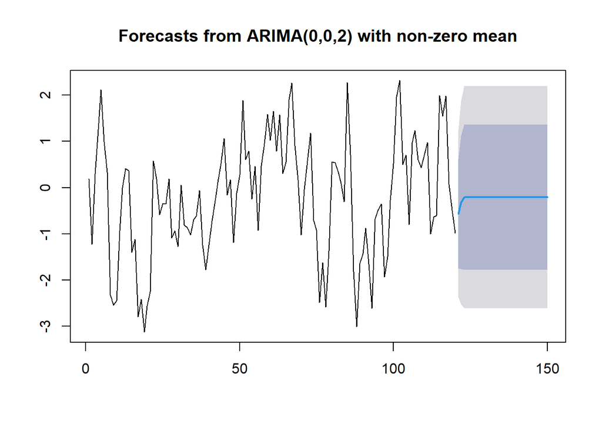

```r
data.ramalan <- ramalan$mean
plot(ramalan)
```

Berdasarkan hasil plot ramalan di atas, dapat dilihat bahwa ramalan ARIMA(0,0,2) cenderung meningkat di awal periode dan stabil hingga akhir periode. Selanjutnya, dapat dicari nilai akurasi antara hasil ramalan dengan data uji sebagai berikut.

```r
perbandingan<-matrix(data=c(ma2.test, data.ramalan),
                     nrow = 30, ncol = 2)
colnames(perbandingan)<-c("Aktual","Hasil Forecast")
perbandingan
```

```
##            Aktual Hasil Forecast
##  [1,] -0.28783640     -0.5618735
##  [2,] -0.64432058     -0.3214588
##  [3,]  1.32792863     -0.2082361
##  [4,] -1.28736112     -0.2082361
##  [5,] -0.51769396     -0.2082361
##  [6,] -0.04258320     -0.2082361
##  [7,]  1.61687328     -0.2082361
##  [8,]  2.11543361     -0.2082361
##  [9,]  0.36342978     -0.2082361
## [10,]  0.02669402     -0.2082361
## [11,]  0.06572631     -0.2082361
## [12,]  2.41852142     -0.2082361
## [13,]  2.45760770     -0.2082361
## [14,]  1.78313790     -0.2082361
```

[output cut: 16 more lines]

```r
accuracy(data.ramalan, ma2.test)
```

```
##                 ME     RMSE       MAE     MPE     MAPE
## Test set 0.5059314 1.242369 0.9656338 103.712 151.7162
```

## Data Asli

Digunakan data kurs yang dalam hal ini hanya digunakan data 500 periode awal

```r
datakurs<-read.csv("https://raw.githubusercontent.com/rizkynurhambali/Praktikum-MPDW-2324/main/Pertemuan%2067/kurs.csv")
datakurs <- datakurs[1:500,]
datakurs.ts<-ts(datakurs)
```

### Eksplorasi Data

#### Plot Data Penuh

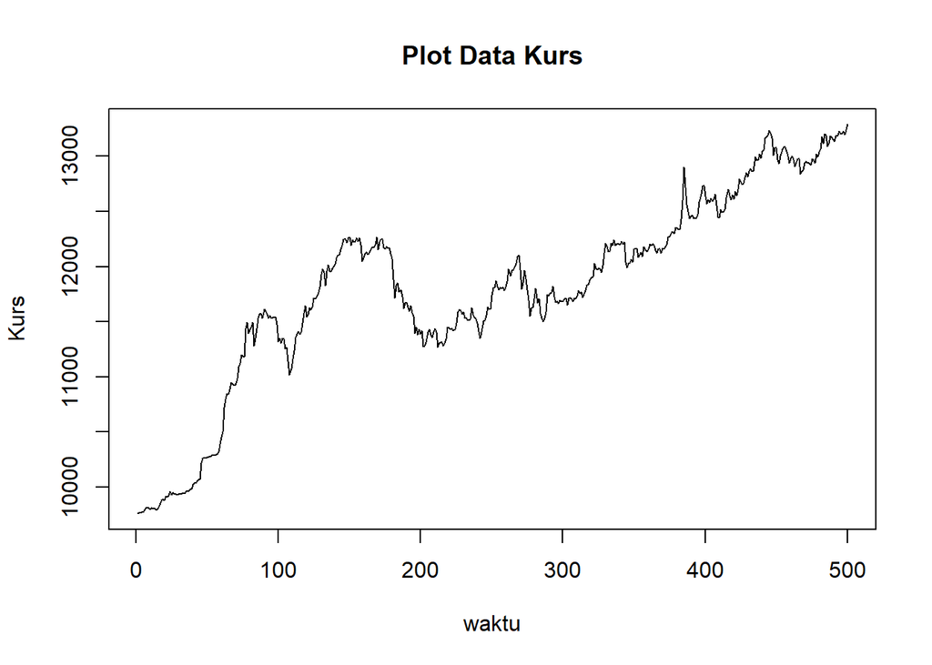

```r
plot.ts(datakurs.ts, lty=1, xlab="waktu", ylab="Kurs", main="Plot Data Kurs")
```

Berdasarkan plot data deret waktu, terlihat bahwa data cenderung memiliki trend yang naik. Berdasarkan pola data, pembagian data latih dan data uji ditetapkan dengan proporsi 86%:14%.

#### Plot Data Latih

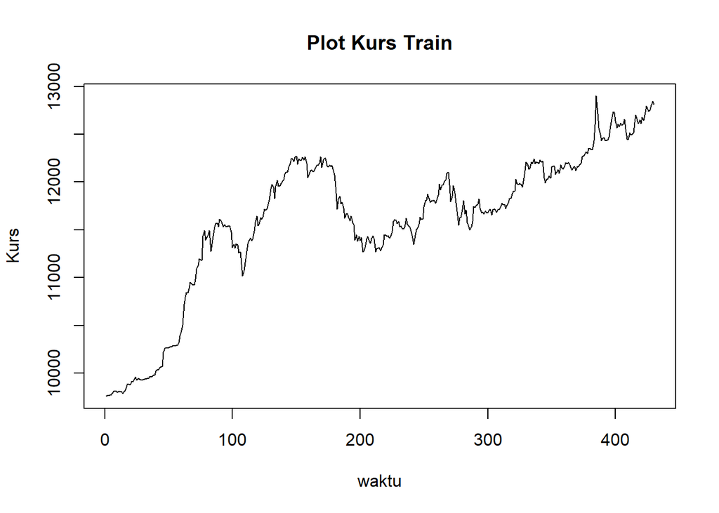

```r
kurstrain<-datakurs[1:430]
train.ts<-ts(kurstrain)
plot.ts(train.ts, lty=1, xlab="waktu", ylab="Kurs", main="Plot Kurs Train")
```

Berdasarkan plot data deret waktu pada data latih, terlihat bahwa data cenderung memiliki trend yang naik dan cenderung tidak bergerak pada nilai tengah tertentu. Hal ini mengindikasikan bahwa data tidak stasioner dalam rataan.

#### Plot Data Uji

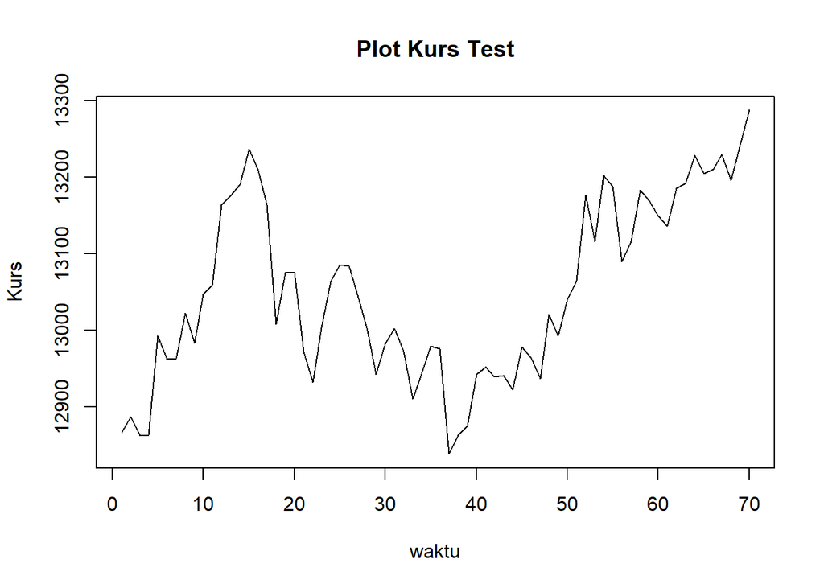

```r
kurstest<-datakurs[431:500]
test.ts<-ts(kurstest)
plot.ts(test.ts, lty=1, xlab="waktu", ylab="Kurs", main="Plot Kurs Test")
```

### Uji Stasioneritas Data

#### Plot ACF

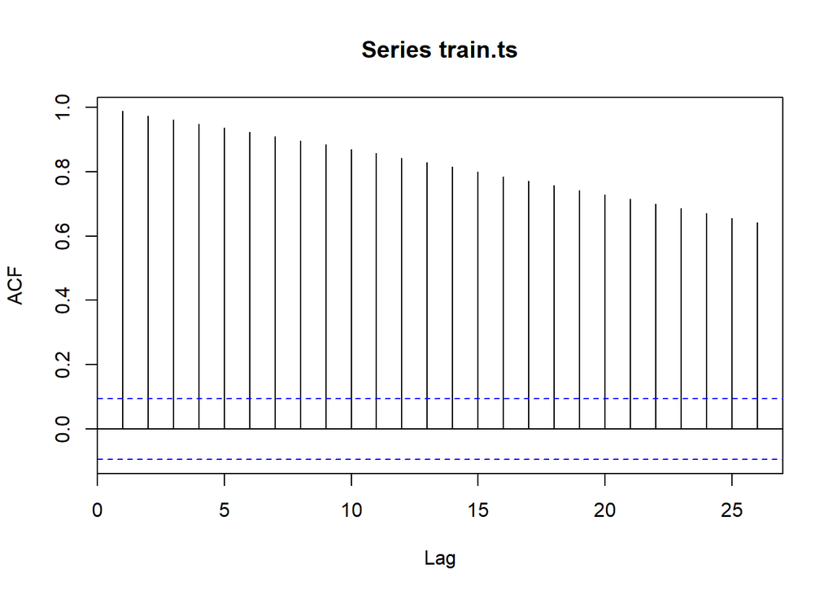

```r
acf(train.ts)
```

Berdasarkan plot ACF, terlihat bahwa plot ACF data menurun secara perlahan (*tails of slowly*). Hal ini juga menjadi indikasi bahwa data tidak stasioner dalam rataan

#### Uji ADF

```r
tseries::adf.test(train.ts)
```

```
##
##  Augmented Dickey-Fuller Test
##
## data:  train.ts
## Dickey-Fuller = -2.0526, Lag order = 7, p-value = 0.5553
## alternative hypothesis: stationary
```

$H_0$ : Data tidak stasioner dalam rataan

$H_1$ : Data stasioner dalam rataan

Berdasarkan uji ADF tersebut, didapat *p-value* sebesar 0.5553 yang lebih besar dari taraf nyata 5% sehingga tak tolak $H_0$ dan menandakan bahwa data tidak stasioner dalam rataan. Hal ini sesuai dengan hasil eksplorasi menggunakan plot time series dan plot ACF, sehingga ketidakstasioneran model kedepannya harus ditangani

#### Plot Box-Cox

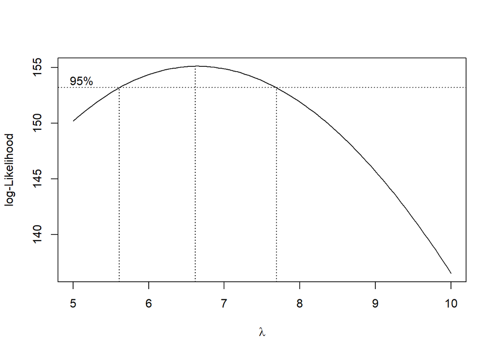

```r
index <- seq(1:430)
bc = boxcox(train.ts~index, lambda = seq(5,10,by=1))
```

```r
#Nilai Rounded Lambda
lambda <- bc$x[which.max(bc$y)]
lambda
```

```
## [1] 6.616162
```

```r
#SK
bc$x[bc$y > max(bc$y) - 1/2 * qchisq(.95,1)]
```

```
##  [1] 5.656566 5.707071 5.757576 5.808081 5.858586 5.909091 5.959596 6.010101
##  [9] 6.060606 6.111111 6.161616 6.212121 6.262626 6.313131 6.363636 6.414141
## [17] 6.464646 6.515152 6.565657 6.616162 6.666667 6.717172 6.767677 6.818182
## [25] 6.868687 6.919192 6.969697 7.020202 7.070707 7.121212 7.171717 7.222222
## [33] 7.272727 7.323232 7.373737 7.424242 7.474747 7.525253 7.575758 7.626263
## [41] 7.676768
```

### Penanganan Ketidakstasioneran Data

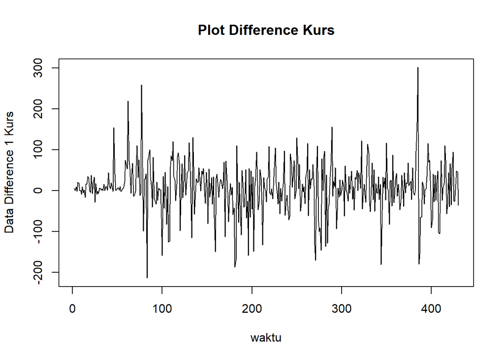

```r
train.diff<-diff(train.ts,differences = 1)
plot.ts(train.diff, lty=1, xlab="waktu", ylab="Data Difference 1 Kurs", main="Plot Difference Kurs")
```

Berdasarkan plot data deret waktu, terlihat bahwa data sudah stasioner dalam rataan ditandai dengan data bergerak pada nilai tengah tertentu (tidak terdapat trend ataupun musiman pada data)

#### Plot ACF

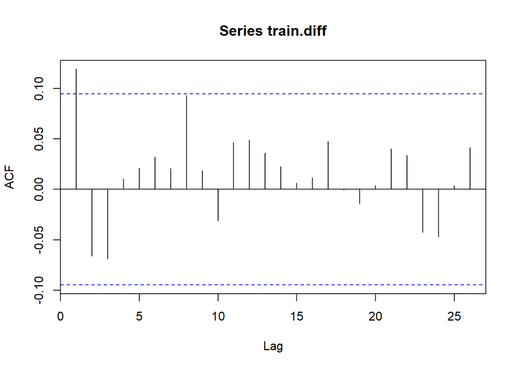

```r
acf(train.diff)
```

Berdasarkan plot tersebut, terlihat bahwa plot ACF cuts off pada lag ke 1. Hal ini menandakan data sudah stasioner dalam rataan dan ketidakstasioneran data telah berhasil tertangani.

#### Uji ADF

```r
tseries::adf.test(train.diff)
```

```
##
##  Augmented Dickey-Fuller Test
##
## data:  train.diff
## Dickey-Fuller = -6.3673, Lag order = 7, p-value = 0.01
## alternative hypothesis: stationary
```

$H_0$ : Data tidak stasioner dalam rataan

$H_1$ : Data stasioner dalam rataan

Berdasarkan uji ADF tersebut, didapat *p-value* sebesar 0.01 yang lebih kecil dari taraf nyata 5% sehingga tolak $H_0$ atau data stasioner dalam rataan. Hal ini sesuai dengan hasil eksplorasi menggunakan plot time series dan plot ACF, sehingga dalam hal ini ketidakstasioneran data sudah berhasil ditangani dan dapat dilanjutkan ke pemodelan

### Identifikasi Model

#### Plot ACF

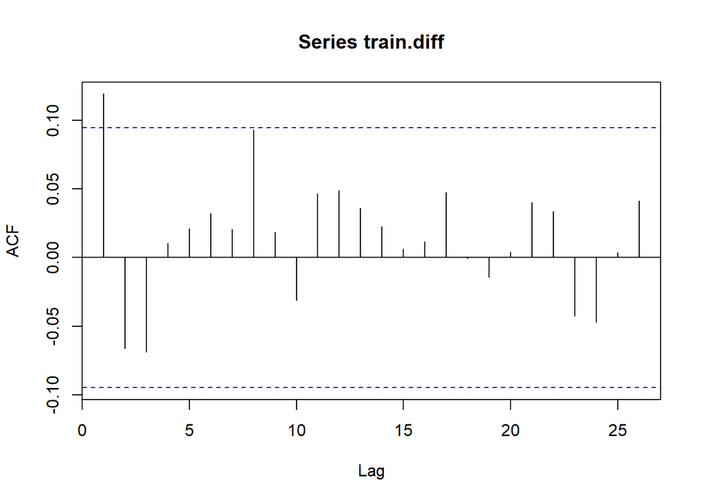

```r
acf(train.diff)
```

Berdasarkan plot tersebut, terlihat bahwa plot ACF cenderung *cuts off* pada lag ke 1, sehingga jika plot PACF dianggap *tails of*, maka model tentatifnya adalah ARIMA(0,1,1).

#### Plot PACF

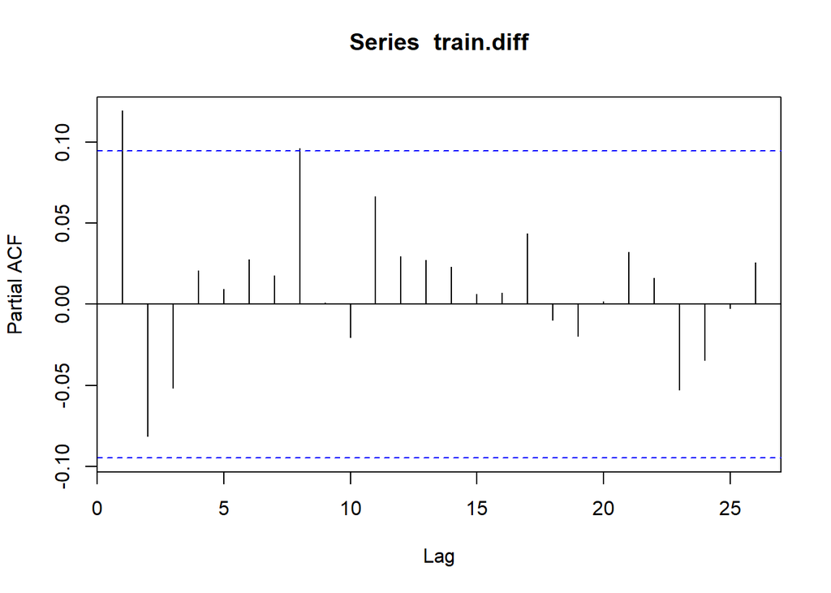

```r
pacf(train.diff)
```

Berdasarkan plot tersebut, terlihat bahwa plot PACF cenderung *cuts off* pada lag ke 1, sehingga jika plot ACF dianggap *tails of*, maka model tentatifnya adalah ARIMA(1,1,0).

Jika baik plot ACF maupun plot PACF keduanya dianggap tails of, maka model yang terbentuk adalah ARIMA(1,1,1)

#### Plot EACF

```r
eacf(train.diff)
```

```
## AR/MA
##   0 1 2 3 4 5 6 7 8 9 10 11 12 13
## 0 x o o o o o o o o o o  o  o  o
## 1 x x o o o o o o o o o  o  o  o
## 2 x x o o o o o o o o o  o  o  o
## 3 x x o o o o o o o o o  o  o  o
## 4 x x x o o o o o o o o  o  o  o
## 5 x x o o o o o o o o o  o  o  o
## 6 x x o o x x o o o o o  o  o  o
## 7 x x o x x x x o o o o  o  o  o
```

### Pendugaan Parameter Model Tentatif

#### ARIMA(0,1,1)

```r
model1.da=Arima(train.diff, order=c(0,1,1),method="ML")
summary(model1.da) #AIC=4753.18
```

```
## Series: train.diff
## ARIMA(0,1,1)
##
## Coefficients:
##           ma1
##       -0.9879
## s.e.   0.0148
##
## sigma^2 = 3835:  log likelihood = -2374.59
## AIC=4753.18   AICc=4753.21   BIC=4761.3
##
## Training set error measures:
##                      ME     RMSE      MAE MPE MAPE      MASE     ACF1
## Training set -0.6762224 61.78387 43.22489 NaN  Inf 0.7363284 0.112352
```

```r
lmtest::coeftest(model1.da) #seluruh parameter signifikan
```

```
##
## z test of coefficients:
##
##      Estimate Std. Error z value  Pr(>|z|)
## ma1 -0.987941   0.014806 -66.727 < 2.2e-16 ***
## ---
## Signif. codes:  0 '***' 0.001 '**' 0.01 '*' 0.05 '.' 0.1 ' ' 1
```

#### ARIMA(1,1,0)

```r
model2.da=Arima(train.diff, order=c(1,1,0),method="ML")
summary(model2.da) #AIC=4917.41
```

```
## Series: train.diff
## ARIMA(1,1,0)
##
## Coefficients:
##           ar1
##       -0.3940
## s.e.   0.0444
##
## sigma^2 = 5676:  log likelihood = -2456.7
## AIC=4917.41   AICc=4917.43   BIC=4925.52
##
## Training set error measures:
##                       ME     RMSE      MAE MPE MAPE      MASE      ACF1
## Training set -0.05787648 75.16292 54.08917 NaN  Inf 0.9213996 -0.121856
```

```r
lmtest::coeftest(model2.da) #seluruh parameter signifikan
```

```
##
## z test of coefficients:
##
##      Estimate Std. Error z value  Pr(>|z|)
## ar1 -0.394037   0.044414 -8.8719 < 2.2e-16 ***
## ---
## Signif. codes:  0 '***' 0.001 '**' 0.01 '*' 0.05 '.' 0.1 ' ' 1
```

#### ARIMA(1,1,1)

```r
model3.da=Arima(train.diff, order=c(1,1,1),method="ML")
summary(model3.da) #AIC=4761.39
```

```
## Series: train.diff
## ARIMA(1,1,1)
##
## Coefficients:
##          ar1      ma1
##       0.1207  -0.9966
## s.e.  0.0491   0.0210
##
## sigma^2 = 3782:  log likelihood = -2371.6
## AIC=4749.21   AICc=4749.27   BIC=4761.39
##
## Training set error measures:
##                     ME     RMSE     MAE  MPE MAPE      MASE        ACF1
## Training set -2.082868 61.28528 43.2876 -Inf  Inf 0.7373967 0.006544589
```

```r
lmtest::coeftest(model3.da) #seluruh parameter signifikan
```

```
##
## z test of coefficients:
##
##      Estimate Std. Error  z value Pr(>|z|)
## ar1  0.120655   0.049064   2.4591  0.01393 *
## ma1 -0.996606   0.020970 -47.5253  < 2e-16 ***
## ---
## Signif. codes:  0 '***' 0.001 '**' 0.01 '*' 0.05 '.' 0.1 ' ' 1
```

#### ARIMA(0,1,2)

```r
model4.da=Arima(train.diff, order=c(0,1,2),method="ML")
summary(model4.da) #AIC=4748.3
```

```
## Series: train.diff
## ARIMA(0,1,2)
##
## Coefficients:
##           ma1      ma2
##       -0.8600  -0.1359
## s.e.   0.0512   0.0507
##
## sigma^2 = 3775:  log likelihood = -2371.15
## AIC=4748.3   AICc=4748.35   BIC=4760.47
##
## Training set error measures:
##                     ME     RMSE      MAE  MPE MAPE      MASE         ACF1
## Training set -2.059629 61.22216 43.24997 -Inf  Inf 0.7367557 -0.009277841
```

```r
lmtest::coeftest(model4.da) #seluruh parameter signifikan
```

```
##
## z test of coefficients:
##
##      Estimate Std. Error z value  Pr(>|z|)
## ma1 -0.860021   0.051204 -16.796 < 2.2e-16 ***
## ma2 -0.135945   0.050725  -2.680  0.007361 **
## ---
## Signif. codes:  0 '***' 0.001 '**' 0.01 '*' 0.05 '.' 0.1 ' ' 1
```

#### ARIMA(1,1,2)

```r
model5.da=Arima(train.diff, order=c(1,1,2),method="ML")
summary(model5.da) #AIC=4749.85
```

```
## Series: train.diff
## ARIMA(1,1,2)
##
## Coefficients:
##           ar1      ma1      ma2
##       -0.1723  -0.6912  -0.3021
## s.e.   0.2443   0.2348   0.2305
##
## sigma^2 = 3782:  log likelihood = -2370.92
## AIC=4749.85   AICc=4749.94   BIC=4766.08
##
## Training set error measures:
##                     ME     RMSE      MAE  MPE MAPE      MASE         ACF1
## Training set -1.798497 61.21036 43.15664 -Inf  Inf 0.7351659 -0.006549048
```

```r
lmtest::coeftest(model5.da) #terdapat parameter tidak signifikan
```

```
##
## z test of coefficients:
##
##     Estimate Std. Error z value Pr(>|z|)
## ar1 -0.17233    0.24425 -0.7056 0.480467
## ma1 -0.69120    0.23481 -2.9436 0.003244 **
## ma2 -0.30214    0.23054 -1.3106 0.189995
## ---
## Signif. codes:  0 '***' 0.001 '**' 0.01 '*' 0.05 '.' 0.1 ' ' 1
```

#### ARIMA(2,1,2)

```r
model6.da=Arima(train.diff, order=c(2,1,2),method="ML")
summary(model6.da) #AIC=4749.52
```

```
## Series: train.diff
## ARIMA(2,1,2)
##
## Coefficients:
##          ar1      ar2      ma1     ma2
##       0.4635  -0.1308  -1.3295  0.3386
## s.e.  0.3091   0.0565   0.3089  0.3073
##
## sigma^2 = 3777:  log likelihood = -2369.76
## AIC=4749.52   AICc=4749.66   BIC=4769.81
##
## Training set error measures:
##                      ME     RMSE     MAE MPE MAPE      MASE         ACF1
## Training set -0.4957896 61.09641 43.1911 NaN  Inf 0.7357528 -0.004047784
```

```r
lmtest::coeftest(model6.da) #terdapat parameter tidak signifikan
```

```
##
## z test of coefficients:
##
##      Estimate Std. Error z value  Pr(>|z|)
## ar1  0.463451   0.309061  1.4995   0.13373
## ar2 -0.130837   0.056523 -2.3148   0.02063 *
## ma1 -1.329455   0.308856 -4.3045 1.674e-05 ***
## ma2  0.338625   0.307281  1.1020   0.27046
## ---
## Signif. codes:  0 '***' 0.001 '**' 0.01 '*' 0.05 '.' 0.1 ' ' 1
```

Berdasarkan pendugaan parameter di atas, nilai AIC terkecil dimiliki oleh model ARIMA(0,1,2) dan parameter model ARIMA(0,1,2) juga seluruhnya signifikan sehingga model yang dipilih adalah model ARIMA(0,1,2).